# Презентация по лабораторной работе № 7

Основы информационной безопасности

Луангсуваннавонг Сайпхачан

# Информация

## Докладчик

- Луангсуваннавонг Сайпхачан
- студент группы НКАбд-01-24
- Российский университет дружбы народов им. П. Лумумбы
- https://github.com/sayprachanh-lsvnv

## Цель работы

Освоить на практике применение режима однократного гаммирования

# Выполнение лабораторной работы

## Выполнение лабораторной работы

Я буду выполнять лабораторную работу на языке программирования Python. Для этой лабораторной работы требуется разработать программу, позволяющую шифровать и дешифровать данные в режиме однократного использования (гаммирования).

Сначала я создаю функцию для генерации случайного ключа с использованием системного генератора случайных чисел.

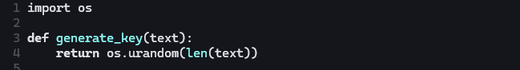

Функция генерирования ключа

## Выполнение лабораторной работы

Согласно примеру в лабораторной работе, необходимо, чтобы все данные отображались в шестнадцатеричном формате, поэтому я создаю функцию, которая преобразует открытый текст в шестнадцатеричный формат.

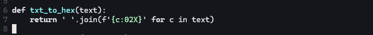

Функция преобразования текстового формата

## Выполнение лабораторной работы

Создание функции, которая выполняет одновременное шифрование и дешифрование с использованием операции “исключающее ИЛИ” (XOR). Поскольку сама операция обратима, я создаю только одну функцию как для шифрования, так и для дешифрования текста.

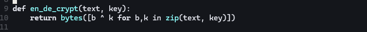

Функция шифрования и дешифрования

## Выполнение лабораторной работы

Необходимо определить ключ, с помощью которого шифротекст можно преобразовать во фрагмент текста, представляющий один из возможных способов прочтения открытого текста. Поэтому я создаю функцию, которая будет находить возможные ключи для различных позиций фрагмента в шифротексте.

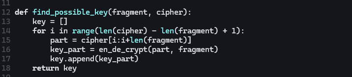

Функция поиска возможного ключа

## Выполнение лабораторной работы

Я запускаю функцию и проверяю результат. Шифрование и дешифрование работают корректно, выдавая результат текста до и после шифрования, а также в шестнадцатеричном формате.

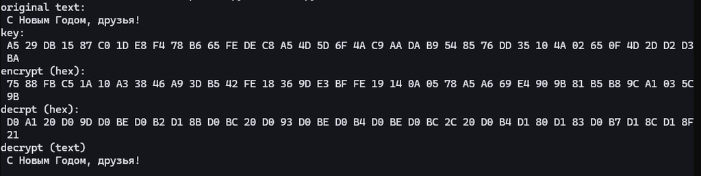

Шифрование и дешифрование

## Выполнение лабораторной работы

А также поиск возможных ключей, которые можно использовать для дешифровки только части текста (фрагмента).

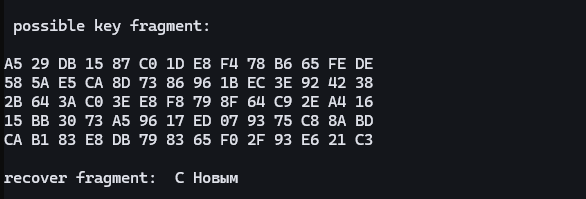

Возможные ключи

# Выводы

в этой лабораторной работе, я освоил на практике применение режима однократного гаммирования